# Height

# 1 Description of DataSchema variable

The description of harmonised variable is the following:

- Short name: `Height`
- Variable label: `Height of the participant`
- Variable description: `Anthropomeric measure for height should be measured in centimeters`
- Domain: `Physical measures`
- Value type: `Continuous`
- Category missings:

| **Code** | **Category Label** |
| --- | --- |
| 991 | CAPI/interviewer error |
| 992 | Impute |
| 993 | Disable to measure |
| 994 | Not attempt/not done |
| 995 | Does not answer |
| 996 | Not applicable |
| 997 | Refuse |
| 998 | Do not know |
| 999 | Missing |

# 2 Data process

## 2.1 England

### 2.1.1 Wave 1

There is no variable.

### 2.1.2 Wave 2

#### 2.1.2.1 Study-specific variable description

The study-specific variable elected to be harmonised is:

- Name: `htval`
- Label: `(D) Valid height (cm)`
- Type of variable: `countinous`
- Missings
  - `-1 = Not Applicable`

```
## $summary
##    Min. 1st Qu.  Median    Mean 3rd Qu.    Max.
##   119.8   158.3   164.9   165.3   172.2   201.4
##
## $values_table
##            No-missings     -1 NA
## Frequency      7330.00 336.00  0
## Percentage       95.62   4.38  0
##
## $n_table
##      Sample size Missing values
## [1,]        7666            336
```

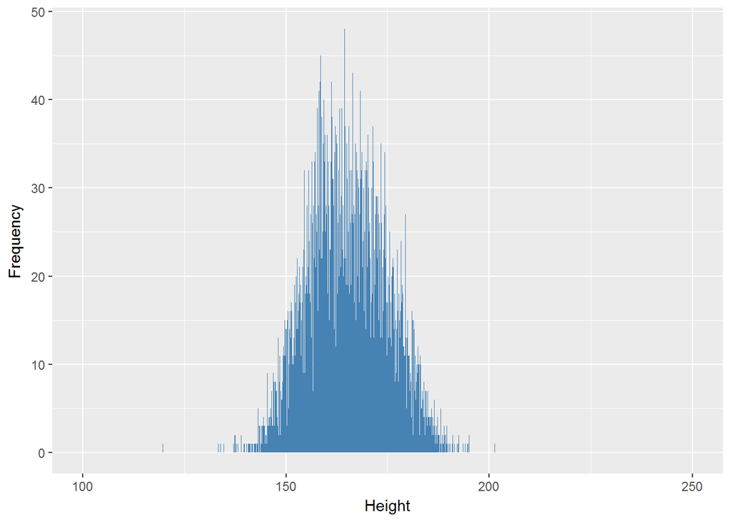

#### 2.1.2.2 Harmonisation algorithm

The harmonized variable is the same than the study-specific variable, but the missing values have to be recoded as follows:

- `recode -1 "Not Applicable" into 996`
- `NA into 999`

**R script:**

```r
ELSA_ds_w2 <- tibble(id = ELSA_w2_heig$id)
ELSA_ds_w2$height <- car::recode(ELSA_w2_heig$htval, "NA=999; -1=996")
ELSA_ds_w2$height <- labelled(ELSA_ds_w2$height, labels = c(Missing = 999, `Do not know` = 998,
    Refuse = 997, `Not applicable` = 996, `Does not answer` = 995, `Not attempt not done` = 994,
    `Disable to measure` = 993, Impute = 992, `CAPI interviewer error` = 991))
```

#### 2.1.2.3 Statistics of the new harmonised variable

```
## $summary
##    Min. 1st Qu.  Median    Mean 3rd Qu.    Max.
##   119.8   158.3   164.9   165.3   172.2   201.4
##
## $values_table
##            No-missings 991 992 993 994 995    996 997 998 999 NA
## Frequency      7330.00   0   0   0   0   0 336.00   0   0   0  0
## Percentage       95.62   0   0   0   0   0   4.38   0   0   0  0
##
## $n_table
##      Sample size Missing values
## [1,]        7666            336
```

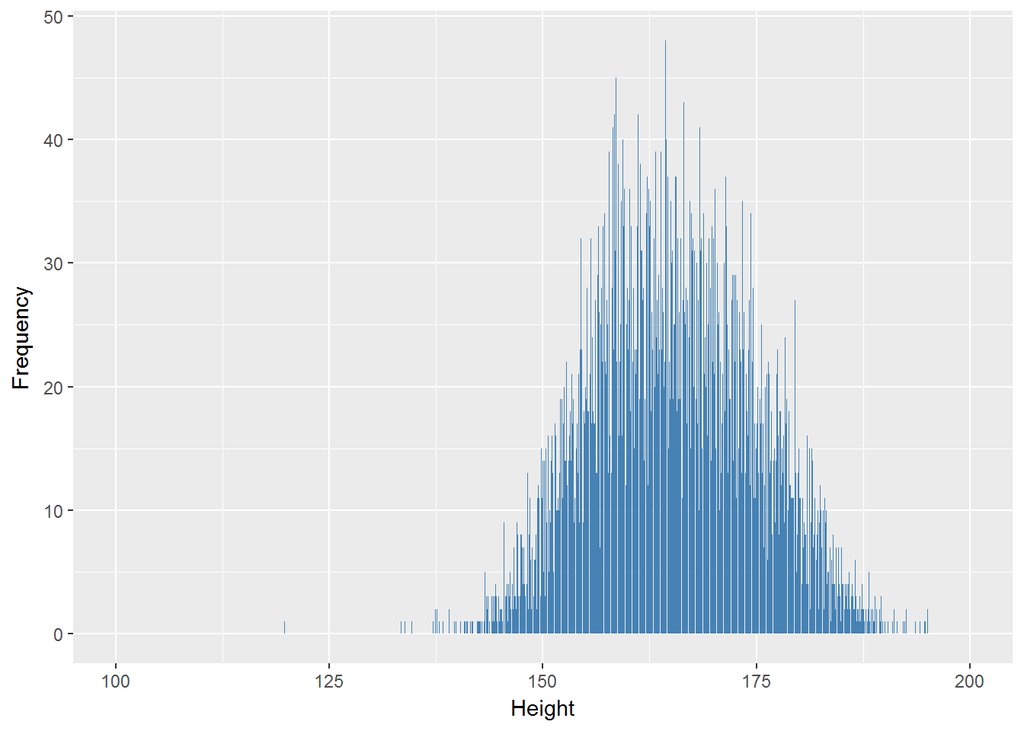

#### 2.1.2.4 Validation

### 2.1.3 Wave 3

There is no variable.

### 2.1.4 Wave 4

#### 2.1.4.1 Study-specific variable description

The study-specific variable elected to be harmonised is:

- Name: `htval`
- Label: `(D) Valid height (cm)`
- Type of variable: `countinous`
- Missings
  - `-1 = Not Applicable`

```
## $summary
##    Min. 1st Qu.  Median    Mean 3rd Qu.    Max.
##   110.5   158.9   165.4   165.7   172.7   207.1
##
## $values_table
##            No-missings     -1 NA
## Frequency      8318.00 325.00  0
## Percentage       96.24   3.76  0
##
## $n_table
##      Sample size Missing values
## [1,]        8643            325
```

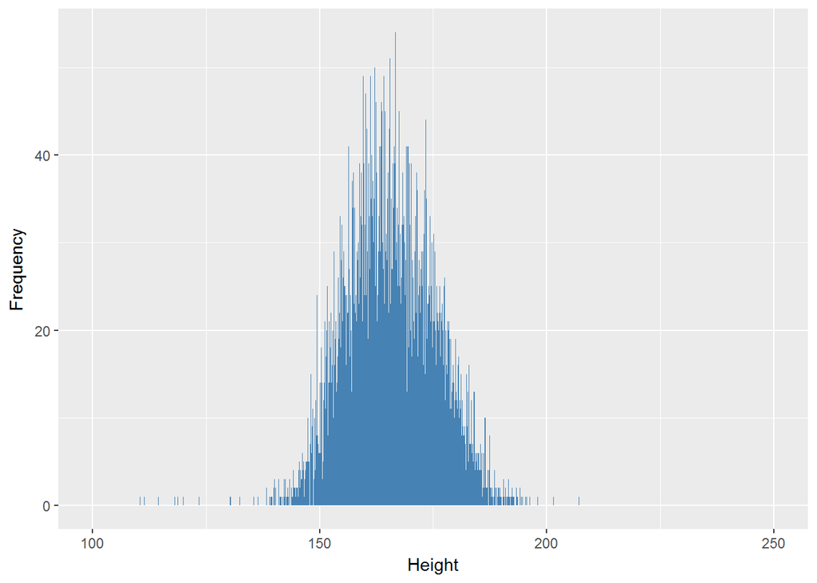

#### 2.1.4.2 Harmonisation algorithm

The harmonized variable is the same than the study-specific variable, but the missing values have to be recoded as follows:

- `recode -1 "Not Applicable" into 996`
- `NA into 999`

**R script:**

```r
ELSA_ds_w4 <- tibble(id = ELSA_w4_heig$id)
ELSA_ds_w4$height <- car::recode(ELSA_w4_heig$htval, "NA=999; -1=996")
ELSA_ds_w4$height <- labelled(ELSA_ds_w4$height, labels = c(Missing = 999, `Do not know` = 998,
    Refuse = 997, `Not applicable` = 996, `Does not answer` = 995, `Not attempt not done` = 994,
    `Disable to measure` = 993, Impute = 992, `CAPI interviewer error` = 991))
```

#### 2.1.4.3 Statistics of the new harmonised variable

```
## $summary
##    Min. 1st Qu.  Median    Mean 3rd Qu.    Max.
##   110.5   158.9   165.4   165.7   172.7   207.1
##
## $values_table
##            No-missings 991 992 993 994 995    996 997 998 999 NA
## Frequency      8318.00   0   0   0   0   0 325.00   0   0   0  0
## Percentage       96.24   0   0   0   0   0   3.76   0   0   0  0
##
## $n_table
##      Sample size Missing values
## [1,]        8643            325
```

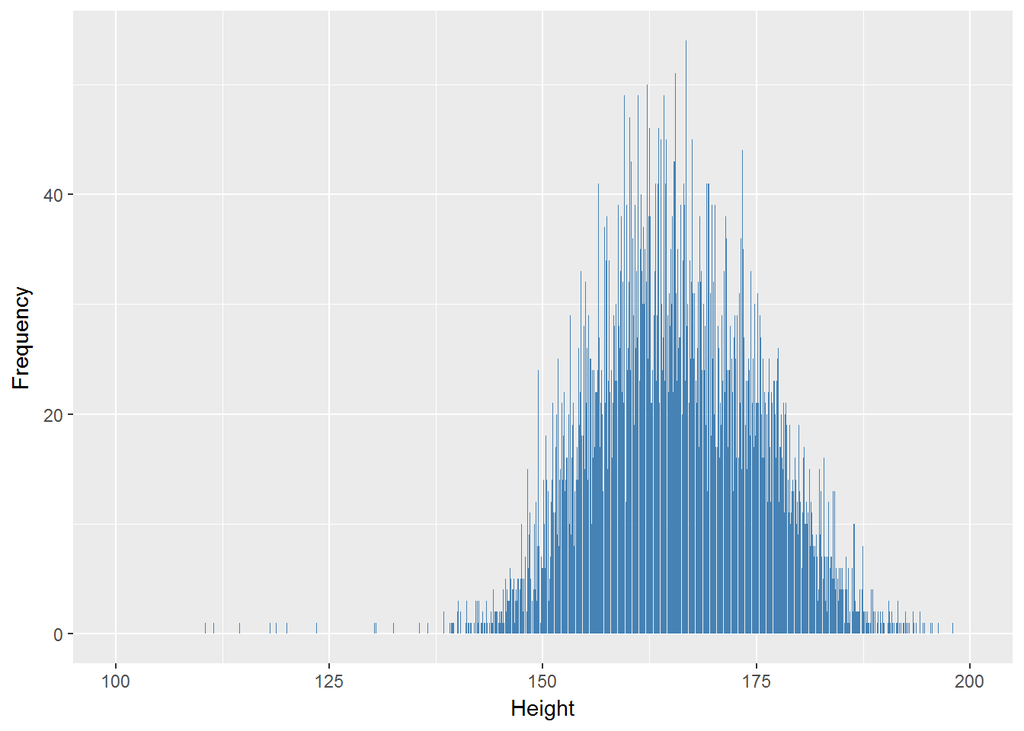

#### 2.1.4.4 Validation

### 2.1.5 Wave 5

There is no variable.

### 2.1.6 Wave 6

#### 2.1.6.1 Study-specific variable description

The study-specific variable elected to be harmonised is:

- Name: `HTVAL`
- Label: `(D) Valid height (cm)`
- Type of variable: `countinous`
- Missings
  - `-1 = Not Applicable`

```
## $summary
##    Min. 1st Qu.  Median    Mean 3rd Qu.    Max.
##   133.9   158.8   165.2   165.7   172.6   202.0
##
## $values_table
##            No-missings     -1 NA
## Frequency      7777.00 277.00  0
## Percentage       96.56   3.44  0
##
## $n_table
##      Sample size Missing values
## [1,]        8054            277
```

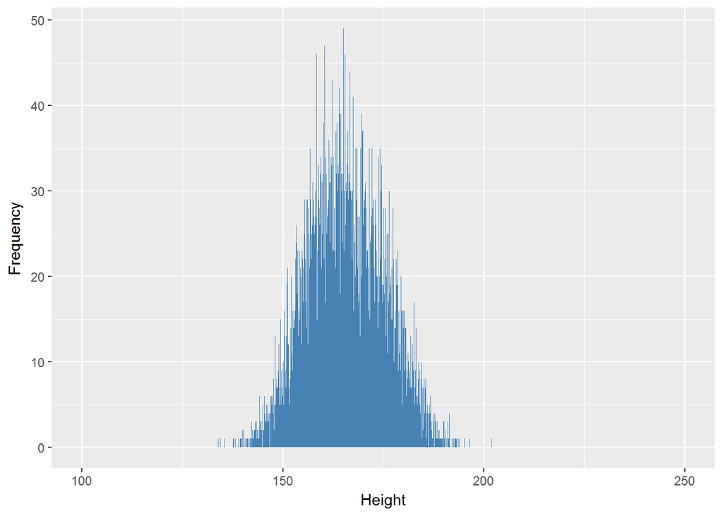

#### 2.1.6.2 Harmonisation algorithm

The harmonized variable is the same than the study-specific variable, but the missing values have to be recoded as follows:

- `recode -1 "Not Applicable" into 996`
- `NA into 999`

**R script:**

```r
ELSA_ds_w6 <- tibble(id = ELSA_w6_heig$id)
ELSA_ds_w6$height <- car::recode(ELSA_w6_heig$HTVAL, "NA=999; -1=996")
ELSA_ds_w6$height <- labelled(ELSA_ds_w6$height, labels = c(Missing = 999, `Do not know` = 998,
    Refuse = 997, `Not applicable` = 996, `Does not answer` = 995, `Not attempt not done` = 994,
    `Disable to measure` = 993, Impute = 992, `CAPI interviewer error` = 991))
```

#### 2.1.6.3 Statistics of the new harmonised variable

```
## $summary
##    Min. 1st Qu.  Median    Mean 3rd Qu.    Max.
##   133.9   158.8   165.2   165.7   172.6   202.0
##
## $values_table
##            No-missings 991 992 993 994 995    996 997 998 999 NA
## Frequency      7777.00   0   0   0   0   0 277.00   0   0   0  0
## Percentage       96.56   0   0   0   0   0   3.44   0   0   0  0
##
## $n_table
##      Sample size Missing values
## [1,]        8054            277
```

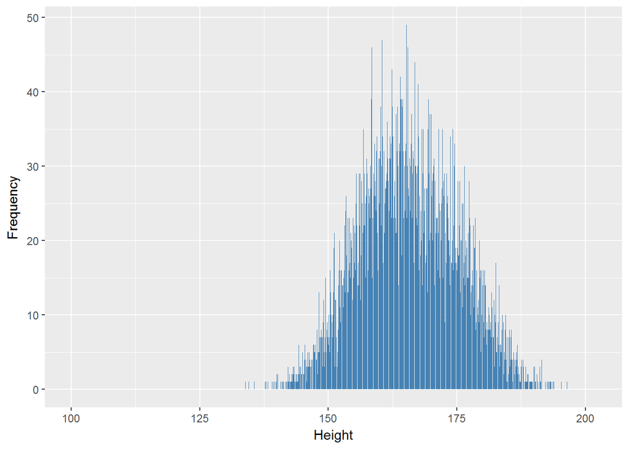

#### 2.1.6.4 Validation

### 2.1.7 Wave 7

Not found.

# 3 Quality estimation